# lecture-03-research-design

## Research Design

FALL 2026 · LECTURE 03

M303

Research Design

Choosing exploratory, descriptive, and causal approaches under uncertainty.

## Where we are

**FROM PROBLEM FORMULATION TO RESEARCH DESIGN**Today we choose the research approach that fits the decision and the level of uncertainty.

01

**Use your name tag**

Help everyone learn names and build a more interactive classroom.

02

**Keep phones, tablets, and laptops away**

Unless they are requested for a class activity.

## Learning Objectives

01**Distinguish the three approaches**

Explain the purpose and main characteristics of exploratory, descriptive, and causal research.

02**Use uncertainty as a guide**

Explain how uncertainty shapes the choice among the three research approaches.

## Prior-class review

P · problemAMP · actionable management problemRO · research objectiveRQ · research questionH · hypothesis

**Classify all 10 statements:**1 P · 1 AMP · 3 RO · 3 RQ · 2 H

Which TV product attributes increase consumers’ quality perceptions the most?

Consumers care about screen quality the most.

Sales of Vizio Model XYZ 4K TV are low because consumers perceive its quality as inferior.

Determine consumers’ additional willingness to pay for each upgraded product attribute.

Which attributes should be improved—screen, sound, color clarity, refresh rate, processor, or price?

Determine which attributes consumers care about the most.

What is the cost of increasing quality for each attribute?

Consumers are willing to pay up to $100 more for a better refresh rate.

Determine the cost of upgrading the attributes.

What additional willingness to pay do consumers have for each upgraded attribute?

## Prior-class review — decision tree

COSGUNER RESEARCH INC.

**Perfect information about the direct-mail conversion rate**

The firm can determine whether the rate is 3% or 1% before the mailing decision.

Research fee · $100,000

YOUR DECISION

ANo direct mailing

BDirect mailing without research

CBuy research first

## Prior-class review — decision-tree solution

Marketing  
research?

YES → observe conversion rate

NO → decide now

**3%**60% probability

**1%**40% probability

Direct mail?

Direct mail?

Direct mail?

## Course access and analysis tools

CANVAS

**Course files in one place**

Lecture materials, instructions, announcements, and required data files will be posted on Canvas.

WEB TOOLS

**Instructor-designed analysis tools**

Hypothesis testing · Regression · Conjoint analysis

koraycosguner.github.io/tools.html

Examples and demonstrations will be presented in class.

## This class

Problem  
formulation

Preliminary stages of marketing research

Research  
design

Choose an appropriate research approach

Data  
collection

Secondary data  
Primary data  
Sampling

Data analysis &  
recommendations

Preparation · Descriptive statistics and cross-tabulations · Hypothesis testing · Correlation and regression

## How do we design and implement marketing research?

01

**Choose the research approach**

Exploratory, descriptive, causal—or a combination.

02

**Choose data sources and methods**

Secondary or standardized data; interviews, focus groups, surveys, or experiments.

03

**Plan measurement and collection**

Design instruments with the analysis in mind, choose a sample, collect the data, and code it.

04

**Analyze and recommend**

Interpret the results and translate them into managerial recommendations.

## Three research approaches

EXPLORATORY

**Discover possible explanations**

Use when little is known about the problem and the goal is to uncover insights, drivers, or decision alternatives.

DESCRIPTIVE

**Measure the current situation**

Provide an accurate snapshot of customers, behaviors, or other aspects of the market environment.

CAUSAL

**Test cause and effect**

Determine whether changing one variable causes a change in another.

## One study can contain all three approaches

LEGACY INDUSTRY STUDY · 2012

**Smart TV sales did not necessarily mean smart-feature use**

- Many households did not use their TVs’ smart functions.
- Users primarily accessed streaming services such as Netflix and Hulu.
- In the original study, 25% of households owned a smart TV.

[figure not shown]

**EXPLORATORY**

How do consumers use smart-TV technology?

**DESCRIPTIVE**

What percentage of households own a smart TV?

**CAUSAL**

What factors increase smart-TV use?

## What characterizes exploratory research?

WHAT?

01

**Little prior knowledge**  
The problem is recognized, but its causes are unclear.

02

**Search for underlying drivers**  
Ask what could be causing the problem.

03

**Flexible, mostly qualitative methods**  
Literature reviews, interviews, and case studies.

04

**Hypotheses are tentative**  
They may be vague or may not yet exist.

## Exploratory research begins with open questions

LUXURY CLOTHING MARKET

**Managers notice a growing group of teenage customers.**

They know only that the customers are teenagers.

Who are these customers?What do they want?

[figure not shown]

## Exploratory findings reveal possible drivers

01

Teenage customers do not necessarily belong to the highest-income group.

02

They save money or ask their parents to buy products.

03

They spend mostly on accessories and shoes.

04

Their preferences can differ from their parents’ preferences.

[figure not shown]

## What characterizes descriptive research?

WHAT?  
WHO · WHERE  
WHEN · HOW

01

**Describe the existing situation**  
Build an accurate snapshot rather than prove causality.

02

**Start with tentative hypotheses**  
The questions are more specific than in exploratory research.

03

**Use structured, quantitative methods**  
Surveys, experiments, and statistical analysis.

04

**Report measurable patterns**  
Example: 50% of people in Indianapolis drink beer once a week.

## What can descriptive research tell us?

DESCRIBE GROUPS

**Who differs from whom?**

How do the demographic characteristics of online buyers differ from those of offline buyers?

ESTIMATE PROPORTIONS

**How common is a behavior?**

What percentage of customers respond to a sales promotion?

COMPARE BEHAVIORS

**Which option is used most?**

Which shopping channels are used most often by retired consumers?

## Descriptive research makes patterns visible

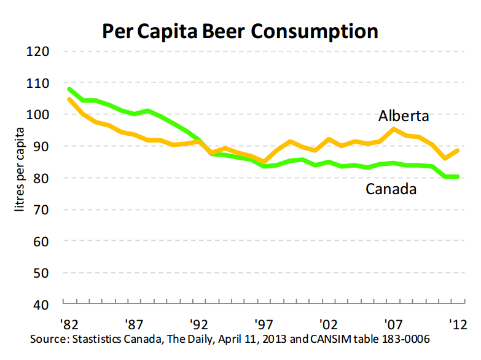

PER-CAPITA BEER CONSUMPTION

**A trend can be described without claiming what caused it.**

The chart compares Alberta with Canada over time. It reveals levels and patterns—not causal mechanisms.

## Cross-buying can look profitable at first

DESCRIPTIVE RESEARCH QUESTION

**Customers who buy across multiple product categories are often assumed to be more profitable.**

Is that always true?

How does cross-buying relate to customer profitability?

PAYMENTS**Credit card**

HOME**Mortgage**

FUTURE**Retirement**

One customer · multiple categories · different service costs

## Cross-buying has a more complicated relationship with profit

01

Across all customers, cross-buying shows a positive relationship with profits.

02

For some customers, cross-buying can be negatively related to profits.

03

Frequent cross-buyers may also complain more and demand more service, creating excessive losses.

HBR · 2012

## What characterizes causal research?

PURPOSE

**Prove that one variable causes another.**

WHY? HOW?

01

The causal factor precedes the outcome.

02

The researcher can manipulate the causal factor.

03

Other variables are fixed or controlled.

04

Hypotheses are specific and the design is carefully structured.

Experiments are the only design that allows researchers to argue causality.

## What questions can causal research address?

BEER COMPANY

Will the new TV commercial lead to stronger consumer preference for our brand?

CHARITY

Will mailing an attractive, more expensive brochure increase contributions from previous donors?

LIFE INSURER

Will using computers for client management increase agents’ sales?

## A causal question: do return policies change purchasing?

ONLINE RETAIL

**Economic research suggested that retailers should toughen online return-shipping policies.**

Customers would pay return shipping when the retailer determined that the customer was at fault.

Does a shift in return policy affect customers’ purchase decisions?

ORDER

**→**

Customer pays return shippingRetailer offers free returns

PURCHASE BEHAVIOR?

## A field experiment isolates the policy effect

Researchers conducted a field experiment with three groups to estimate how return policies affected consumers’ online purchase spending.

01**Pay for returns**

Customers paid return shipping.

**↓ 75%–100%**spending decreased

02**Free returns**

Customers were offered free return shipping.

**↑ 158%–457%**spending increased

03**Control**

No return policy was offered.

**Comparison group**

Reported ranges are retained from the original lecture.

## Uncertainty guides the research approach

HIGH AMBIGUITYLOW AMBIGUITY

**EXPLORATORY****Ambiguous problem**

Discover plausible explanations.

**DESCRIPTIVE****Problem recognized**

Measure the situation and patterns.

**CAUSAL****Problem clearly defined**

Test a specific cause-and-effect claim.

## The detective funnel combines the approaches

**Many studies use a combination of all three approaches.**

**EXPLORE**

Generate a broad set of possible explanations.

**DESCRIBE**

Measure which patterns are present and how common they are.

**TEST**

Narrow the plausible causes with causal evidence.

POSSIBLE EXPLANATIONS

MEASURED PATTERNS

LIKELY CAUSE

## In-class exercise 1

WORK WITH YOUR GROUP

Choose a marketing research problem or opportunity at a firm that interests you.

State the problem or opportunity and the actionable management decision.State research objectives and research questions.State your hypotheses.

## In-class exercise 2

BUILD ON EXERCISE 1

Formulate research questions or hypotheses that can be addressed with each research approach.

At least one exploratory questionAt least one descriptive questionAt least one causal question or hypothesis

## To sum up

01

**Exploratory**

Discover what might be happening.

02

**Descriptive**

Measure what is happening.

03

**Causal**

Test why it is happening.

**Choose based on uncertainty and the research question.**Many studies move through more than one approach.

## Next class

COMING NEXT

Sources of  
Secondary Data

01Problem formulation

02Research design

03Data collection

04Data analysis & recommendations

How can existing information answer a new marketing question?